# Исследование структуры временных рядов в R (альтернативная версия)

Заходякин Г.В., postlogist@gmail.com

# Введение

В этом блокноте разобраны примеры анализа регулярных временных рядов из Единой межведомственной информационной системы (http://fedstat.ru) и Росстата (http://gks.ru).

Пример анализа временных рядов из Единого архива экономических и социологических данных НИУ ВШЭ (http://sophist.ru) рассмотрены в файле `decomposition_tutorial.Rmd`.

Рекомендуем также ознакомиться со следующими примерами:

- time_series.Rmd - загрузка и сохранение данных временного ряда
- dygraphs_tutorial.Rmd - визуализация временных рядов с возможностью интерактивного исследования данных

```r
library(tidyverse) # ggplot2 и трансформация данных
library(readxl) # Загрузка экселей
library(forecast) # анализ временных рядов и прогнозирование
library(lubridate) # операции с датами
#library(stringr)  # Работа с текстовыми строками
```

# Подготовка данных

## Как загрузить данные из Excel

Исходный файл данных - Оборот розничной торговли в Российской Федерации data/fedstat_retail.xls, название листа - `Данные`.

Источник - [система ЕМИСС](https://fedstat.ru/indicator/31260)

Единица измерения - млн руб.

```r
retail_raw <- read_excel('data/fedstat_retail.xls',
                       sheet = 'Данные',
                       skip = 2 # Пропустить 2 строки вверху листа
)
```

```
## * `` -> ...1
## * `` -> ...2
## * `` -> ...3
```

```r
head(retail_raw)
```

```
## # A tibble: 6 x 4
##   ...1  ...2  ...3    `Российская Федерация`
##   <chr> <chr> <chr>                    <dbl>
## 1 Всего 2000  январь                 170269.
## 2 Всего 2000  февраль                168132.
## 3 Всего 2000  март                   179342.
## 4 Всего 2000  апрель                 177761.
## 5 Всего 2000  май                    179780.
## 6 Всего 2000  июнь                   185232.
```

Данные загрузились как числовые значения. В файле содержатся ежемесячные наблюдения начиная с января 2000 года. Исправим имена столбцов:

```r
names(retail_raw) <- c('metric', 'year', 'month', 'turnover')
head(retail_raw)
```

```
## # A tibble: 6 x 4
##   metric year  month   turnover
##   <chr>  <chr> <chr>      <dbl>
## 1 Всего  2000  январь   170269.
## 2 Всего  2000  февраль  168132.
## 3 Всего  2000  март     179342.
## 4 Всего  2000  апрель   177761.
## 5 Всего  2000  май      179780.
## 6 Всего  2000  июнь     185232.
```

Для визуализации данных средствами ggplot получим столбец с датами наблюдений на основе имеющихся столбцов с годом и месяцем. Наблюдение отнесем к 1 числу месяца. Удалим лишние столбцы `metric`. Пересчитаем оборот из млн руб. в млрд руб.

```r
retail_tbl <-
  retail_raw %>%
  mutate(date = ymd(paste(year, month, 1))) %>%
  select(date, turnover) %>%
  mutate(turnover = turnover / 1000)

retail_tbl %>% head()
```

```
## # A tibble: 6 x 2
##   date       turnover
##   <date>        <dbl>
## 1 2000-01-01     170.
## 2 2000-02-01     168.
## 3 2000-03-01     179.
## 4 2000-04-01     178.
## 5 2000-05-01     180.
## 6 2000-06-01     185.
```

Полученную таблицу данных можно визуализировать средствами ggplot, чтобы проверить, нет ли в ней пропусков. Дальнейшая работа с данными ряда требует, чтобы наблюдения были регулярными, без пропущенных периодов.

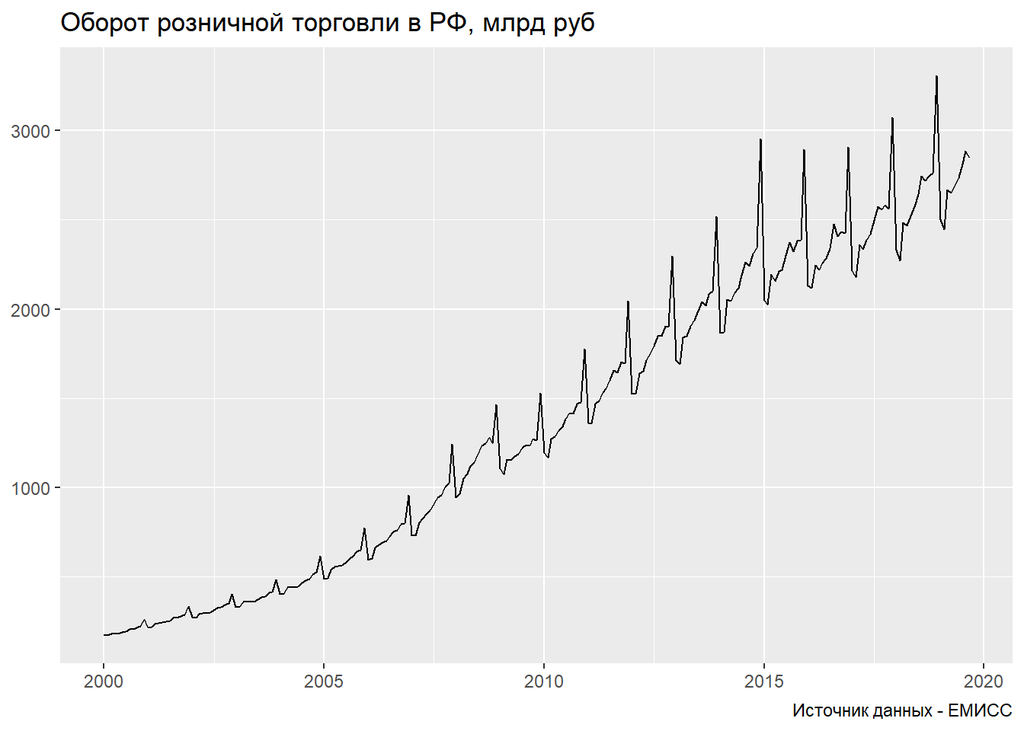

```r
# Запоминаем название ряда и источник для графиков
retail_title <- 'Оборот розничной торговли в РФ, млрд руб'
retail_source <- 'Источник данных - ЕМИСС'


# Визуализация
retail_tbl %>%
  ggplot(aes(date, turnover)) +
  geom_line() +
  labs(title = retail_title,
       caption = retail_source,
       y = NULL, x = NULL)
```

## Как сделать временной ряд `ts`

В R есть множество форматов представления временных рядов. Инструменты для анализа временных рядов из базового R и из пакета `forecast` работают только с регулярными временными рядами класса `ts`.

Временной ряд `ts` состоит из **наблюдений** и **индекса**. В качестве индекса используется возрастающая последовательность чисел (обычно это годы). Если ряд содержит более частые наблюдения - например, ежемесячные или ежеквартальные, то необходимо задать **частоту** ряда (*frequency*), т.е. количество наблюдений в течение года.

При создании ряда необходимо указать, что данные начинаются с 1 месяца 2000 года, а частота равна 12, т.к. данные ежемесячные.

```r
# Найдем автоматически год и месяц начала наблюдений:

retail_first <-
  retail_tbl %>%
  summarize(year = year(first(date)),
            month = month(first(date)))
retail_first
```

```
## # A tibble: 1 x 2
##    year month
##   <dbl> <dbl>
## 1  2000     1
```

Создадим временной ряд ts. Для этого укажем столбец с данными, начальный период - (год, месяц) и частоту (12).

```r
retail_ts <-
  ts(data = retail_tbl$turnover,
            start = c(retail_first$year, retail_first$month),
            frequency = 12)

retail_ts %>% tail(n = 21) %>% round()
```

```
##       Jan  Feb  Mar  Apr  May  Jun  Jul  Aug  Sep  Oct  Nov  Dec
## 2018 2330 2272 2486 2469 2523 2573 2644 2744 2719 2745 2763 3312
## 2019 2503 2448 2670 2650 2693 2735 2797 2886 2849
```

# Анализ временного ряда

## Визуализация

Функции базовой графики R могут работать с временными рядами `ts` непосредственно. Для визуализации временного ряда средствами `ggplot2` необходимо использовать функцию `autoplot()` пакета `forecast`. В результате получается объект, с которым можно продолжить работу стандартными средствами `ggplot2`.

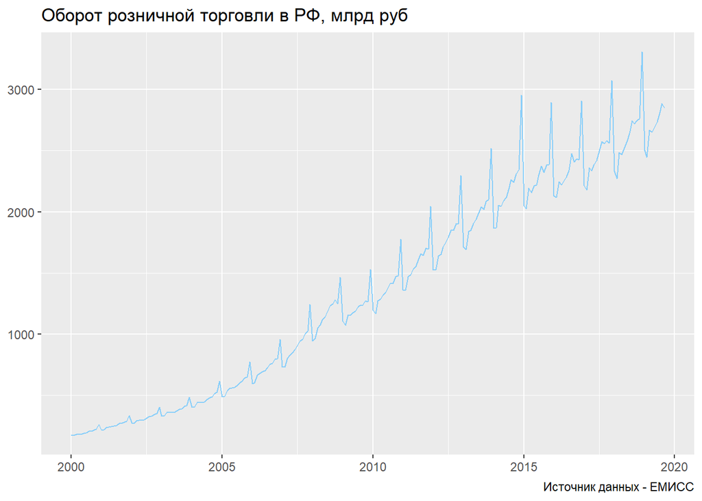

```r
autoplot(retail_ts) +
  labs(title = retail_title, caption = retail_source, x = NULL, y = NULL) +
  geom_line(color = 'lightSkyblue')
```

Справку по использованию функции можно получить командой: `?autoplot.ts` или [онлайн](https://www.rdocumentation.org/packages/forecast/versions/8.9/topics/autolayer.mts).

## Классическая сезонная декомпозиция

Декомпозиция временного ряда позволяет выделить отдельные его компоненты - тренд, сезонность и нерегулярные изменения (остаток).

Форма графика временного ряда позволяет предположить наличие тренда и сезонных колебаний мультипликативного типа.

Вначале воспользуемся встроенной функцией R - `decompose()`, реализующей метод классической декомпозиции на основе скользящего среднего. Визуализировать результаты можно с помощью функции `autoplot()`

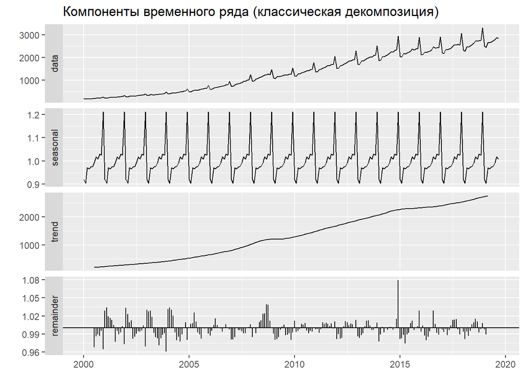

```r
retail_d <- retail_ts %>%
  decompose(type = 'multiplicative')

autoplot(retail_d) +
  labs(title = 'Компоненты временного ряда (классическая декомпозиция)',
       x = NULL)
```

Результат декомпозиции имеет множество применений, например:

- Легче сравнивать временные ряды, если исключить сезонные изменения.
- Легче выявлять нерегулярные изменения, не укладывающиеся в регулярные сезонные колебания.
- Можно скомбинировать компоненты, чтобы получить прогноз.
- После исключения сезонности и/или тренда из временного ряда результат можно описать с помощью более простой модели. Получив прогноз с помощью более простой модели, можно “вернуть” исключенные компоненты.
- Данные о сезонности гораздо более устойчивы, чем данные о тренде. Это может быть полезно при прогнозировании в кризисный период: сезонность сохраняется, а направление тренда резко изменяется из-за спада в экономике.

Для извлечения компонентов ряда можно использовать их имена (`x` - исходный ряд, `seasonal` и `trend` - закономерные компоненты, `random` - остаток):

```r
names(retail_d)
```

```
## [1] "x"        "seasonal" "trend"    "random"   "figure"   "type"
```

Однако удобнее пользоваться специальными функциями пакета `forecast`:

```r
# Сезонные индексы
retail_d %>% seasonal() %>% head(12) %>% round(1)
```

```
##      Jan Feb Mar Apr May Jun Jul Aug Sep Oct Nov Dec
## 2000 0.9 0.9 1.0 1.0 1.0 1.0 1.0 1.0 1.0 1.0 1.0 1.2
```

```r
# Тренд-циклическая компонента
retail_d %>% trendcycle() %>% head(12) %>% round(1)
```

```
##        Jan   Feb   Mar   Apr   May   Jun   Jul   Aug   Sep   Oct   Nov
## 2000    NA    NA    NA    NA    NA    NA 197.9 201.7 206.0 210.8 216.0
##        Dec
## 2000 221.3
```

```r
# Остаток
retail_d %>% remainder() %>% head(12) %>% round(1)
```

```
##      Jan Feb Mar Apr May Jun Jul Aug Sep Oct Nov Dec
## 2000  NA  NA  NA  NA  NA  NA   1   1   1   1   1   1
```

Рассмотрим отдельно компоненты ряда. Для сравнения, будем изображать компоненты поверх исходного ряда

**Тренд**

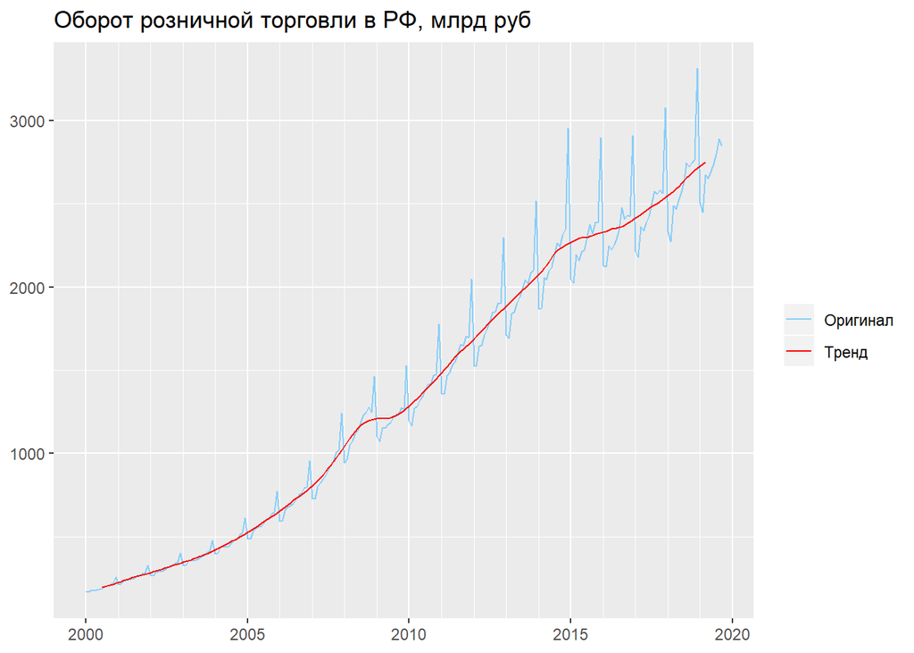

```r
autoplot(retail_ts, series = 'Оригинал') +
  autolayer(trendcycle(retail_d), series = 'Тренд') +
  labs(color = NULL, x = NULL, y = NULL,
       title = retail_title) +
  scale_color_manual(values = c('lightskyblue', 'red')) +
  scale_x_continuous(minor_breaks = start(retail_ts):end(retail_ts))
```

Обратим внимание на то, что линия тренда короче исходного ряда. Это вызвано тем, что функция `decompose()` использует для выделения тренда скользящее среднее с окном, равным частоте временного ряда (12). В результате, по 6 периодов в начале и в конце ряда теряются, т.к. скользящее окно усреднения выходит в эти периоды за пределы данных и среднее не может быть вычислено.

На графике трендциклической компоненты виден спад во время кризисов 2008 и 2015 года.

**Сезонный компонент**

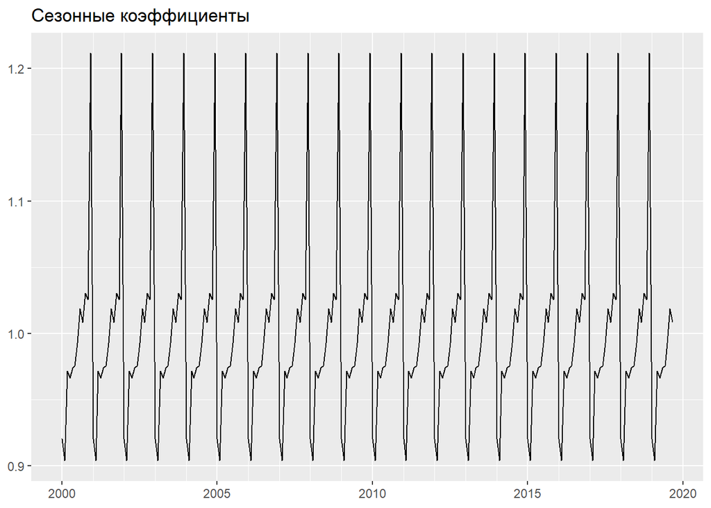

```r
autoplot(seasonal(retail_d)) +
  labs(y = NULL, x = NULL,
       title = 'Сезонные коэффициенты') +
  scale_x_continuous(minor_breaks = start(retail_ts):end(retail_ts))
```

В методе классической декомпозиции сезонные коэффициенты получаются с помощью усреднения наблюдений для одноименных месяцев после удаления тренда, поэтому наборы сезонных коэффициентов для всех лет одинаковы.

**Модель ряда**

Модель ряда получается путем сочетания выделенных закономерных компонентов. Сравним результат с исходными данными.

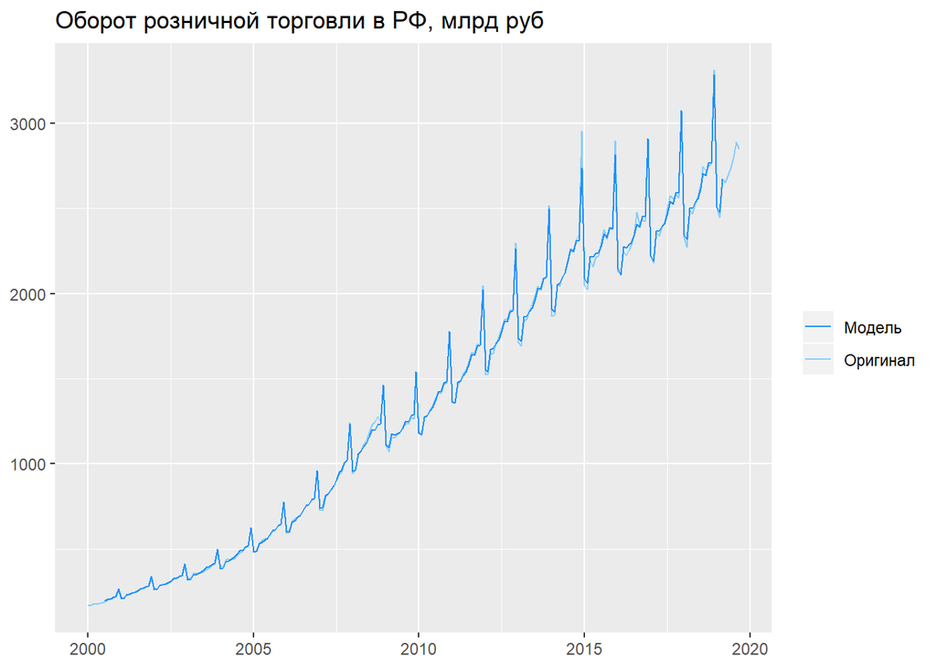

```r
autoplot(retail_ts, series = 'Оригинал') +
  autolayer(trendcycle(retail_d) * seasonal(retail_d),
            series = 'Модель') +
  scale_colour_manual(values = c('dodgerblue', 'lightskyblue')) +
  labs(y = NULL, color = NULL, x = NULL,
       title = retail_title)
```

Результат близок к оригиналу, однако виды расхождения. Эти расхождения - **остатки**, или ошибки модели. Их также называют нерегулярным (случайным) компонентом ряда.

**Остатки**

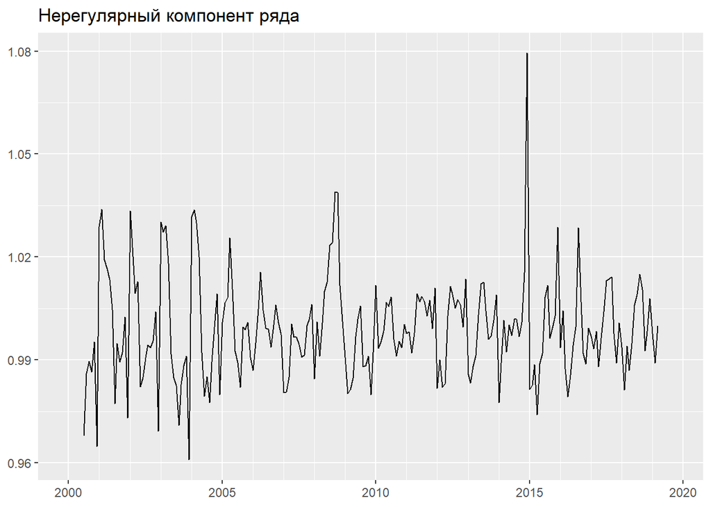

```r
autoplot(remainder(retail_d)) +
  labs(y = NULL, x = NULL,
       title = 'Нерегулярный компонент ряда') +
  scale_x_continuous(minor_breaks = start(retail_ts):end(retail_ts))
```

Заметны регулярные колебания остатков, следовательно, закономерные компоненты исключены не полностью. Это - следствие того, что на протяжении выбранного для анализа периода величина сезонных коэффициентов менялась, но классическая декомпозиция не позволила этого учесть. Следовательно, необходимо использовать другой метод и/или сократить количество наблюдений временного ряда.

## Сезонная корректировка ряда

Сезонная корректировка ряда позволяет исключить влияние сезонных колебаний. Это облегчает анализ краткосрочных изменений ряда, которые иначе не видны из-за сезонности. Для выполнения сезонной корректировки в R можно использовать функцию `forecast::seasadj()`. Эта функция принимает в качестве аргумента объект, созданный одной из функций для декомпозиции.

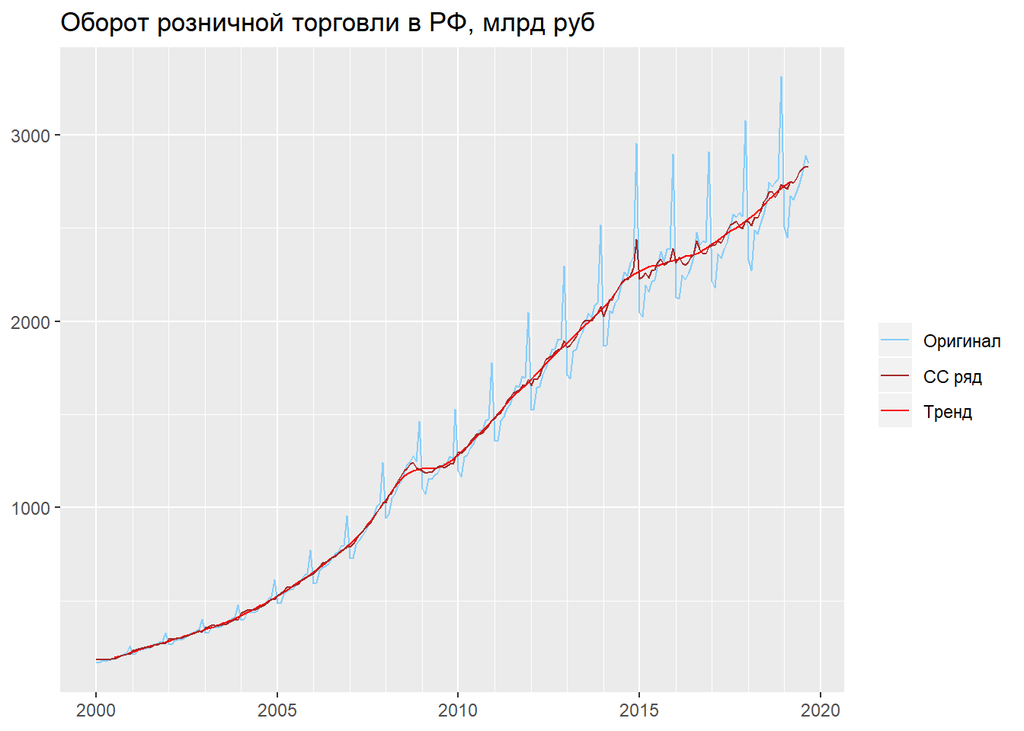

```r
retail_adj <- seasadj(retail_d)


autoplot(retail_ts, series = 'Оригинал') +
  autolayer(trendcycle(retail_d), series = 'Тренд') +
  autolayer(retail_adj, series = 'СС ряд') +
  scale_colour_manual(values = c('lightskyblue', 'brown', 'red')) +
  labs(y = NULL, color = NULL, x = NULL,
       title = retail_title) +
  scale_x_continuous(minor_breaks = start(retail_ts):end(retail_ts))
```

В отличие от сильно сглаженной линии тренда, график сезонно-скорректированный ряд содержит случайные колебания уровня. Наш ряд имеет мультипликативную структуру, поэтому его модель может быть описана формулой:

$$y = T \cdot S \cdot E,$$

где $T$ - тренд, $S$ - сезонный коэффициент, $E$ - случайная (нерегулярная) составляющая, или ошибка, $y$ - наблюдаемое значение ряда.

Тренд - это только компонент $T$, а ряд с исключенной сезонностью получается с помощью деления:

$$A = \frac{y}{S} = T \cdot E.$$

В отличие от тренда, временной ряд с удаленной сезонностью содержит случайную составляющую $E$.

Аналогичного результата можно добиться и с помощью непосредственного деления исходного ряда на сезонные коэффициенты:

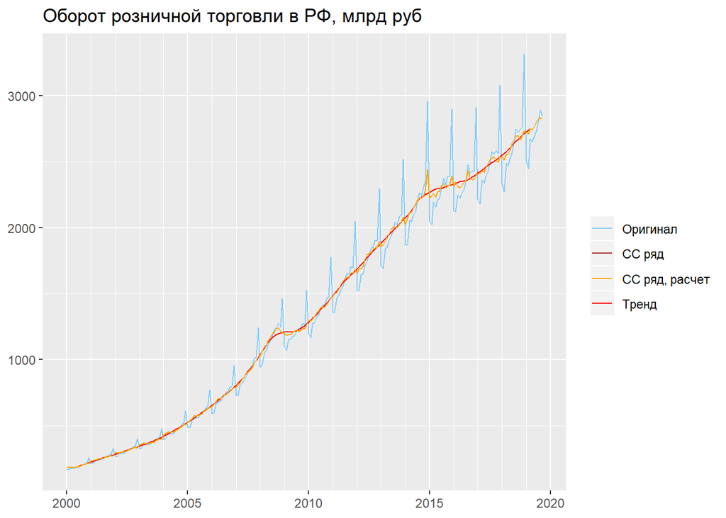

```r
autoplot(retail_ts, series = 'Оригинал') +
  autolayer(trendcycle(retail_d), series = 'Тренд') +
  autolayer(retail_adj, series = 'СС ряд') +
  autolayer(retail_ts/seasonal(retail_d), series = 'СС ряд, расчет') +
  scale_colour_manual(values = c('lightskyblue', 'brown', 'orange', 'red')) +
  labs(y = NULL, color = NULL, x = NULL,
       title = retail_title) +
  scale_x_continuous(minor_breaks = start(retail_ts):end(retail_ts))
```

Ряд с исключенной сезонностью содержит значения во всех периодах, т.к. для его вычисления используются непосредственно значения исходного ряда и сезонные коэффициенты. Сезонные коэффициенты - одни и те же для всех лет временного ряда, поэтому пустых периодов данных нет.

## Исключение тренда

Подобным же образом, можно удалить из ряда тренд, чтобы облегчить анализ изменений сезонного цикла.

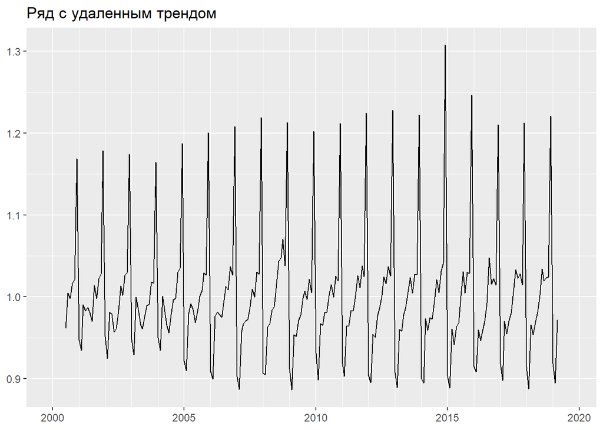

```r
retail_detrended <- retail_ts/trendcycle(retail_d)

autoplot(retail_detrended) +
  labs(y = NULL, color = NULL, x = NULL,
       title = 'Ряд с удаленным трендом') +
  scale_x_continuous(minor_breaks = start(retail_ts):end(retail_ts))
```

В пакете `forecast` имеется функция для визуализации отличий сезонных колебаний в разные годы - `ggseasonplot()`. В зависимости от задачи, более наглядным может оказаться применение этой функции к ряду с удаленным трендом.

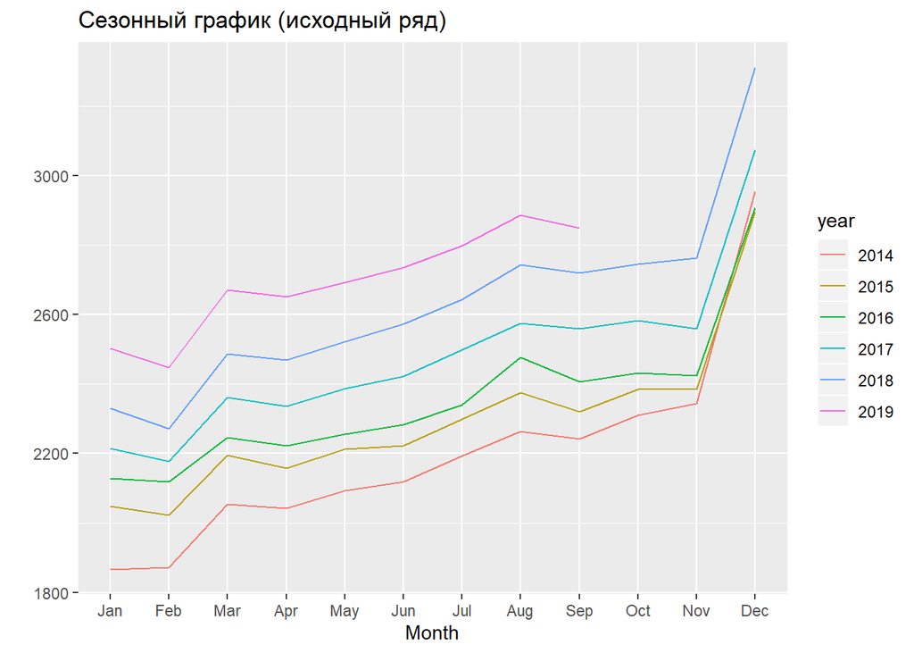

```r
# Исходный ряд
retail_ts %>%
  window(start = 2014) %>%
  ggseasonplot() +
  labs(title = 'Сезонный график (исходный ряд)')
```

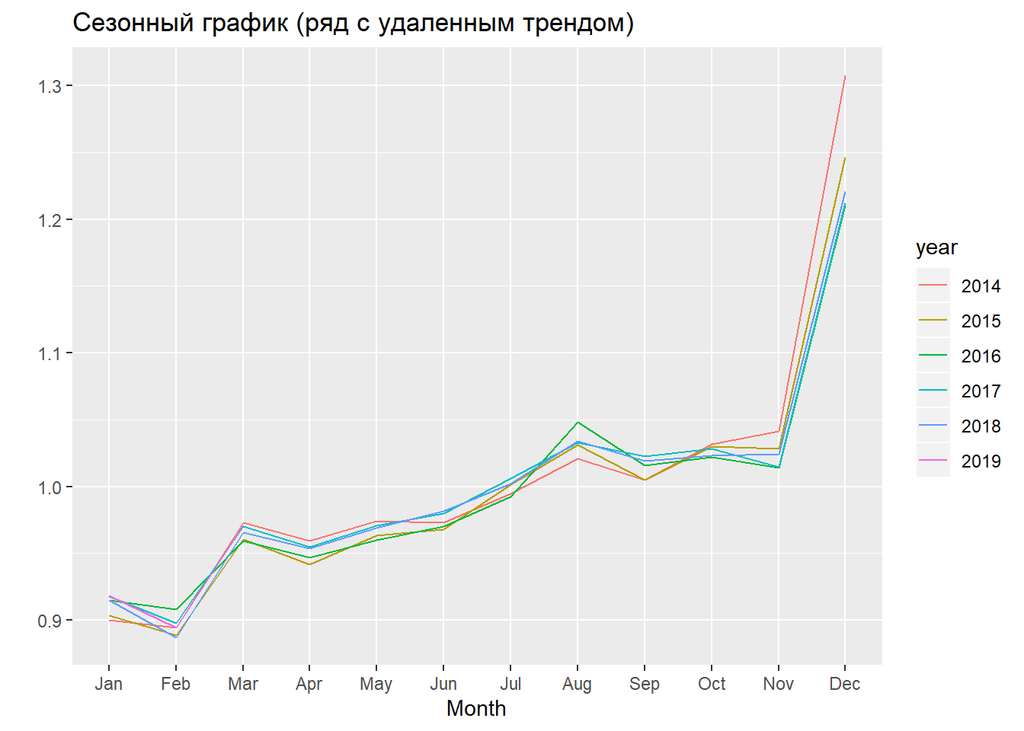

```r
# Ряд с удаленным трендом
retail_detrended %>%
  window(start = 2014) %>%
  ggseasonplot() +
  labs(title = 'Сезонный график (ряд с удаленным трендом)')
```

## STL-декомпозиция

Теперь выполним декомпозицию, используя функцию `forecast::stl()` (*Seasonal and Trend decomposition using Loess*). Данная функция также выделяет тренд с помощью сглаживания, но использует вместо скользящего среднего метод локальной регрессии - LOESS. Это позволяет исключить потерю данных на концах ряда. Кроме того, метод более устойчив к выбросам в данных ряда.

Недостатком этого подхода является поддержка сезонности только аддитивного типа. Большинство экономических временных рядов - мультипликативные.

Для решения этой проблемы можно либо разрешить сезонным компонентам ряда постепенно меняться (используя параметр `s.window` функции `stl()`), либо преобразовать данные, чтобы превратить мультипликативный характер сезонности в аддитивный.

### Изменяющиеся сезонные коэффициенты

Обязательный параметр `s.window` функции `stl()` задает ширину окна для сглаживания ряда методом LOESS при извлечении сезонного компонента. Значение параметра должно быть нечетным и не менее 7. Также можно задать `s.window = 'periodic'`, тогда набор сезонных коэффициентов будет одним и тем же для всех лет.

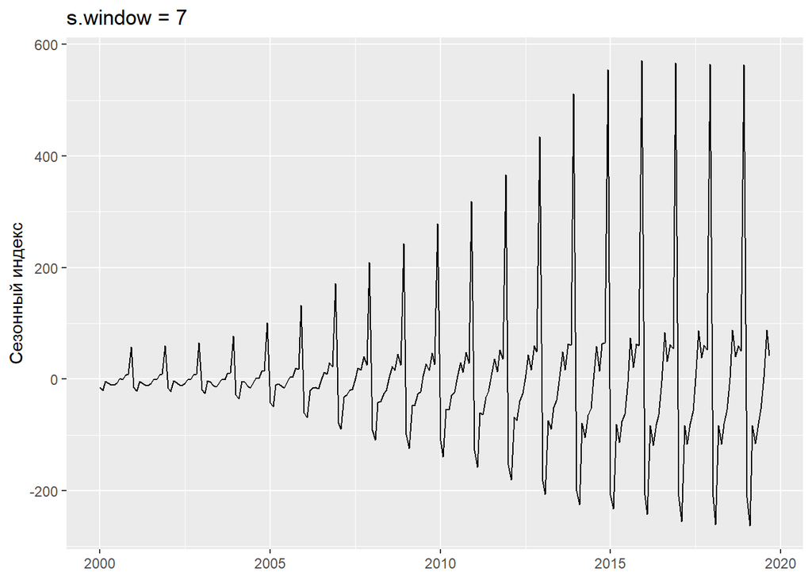

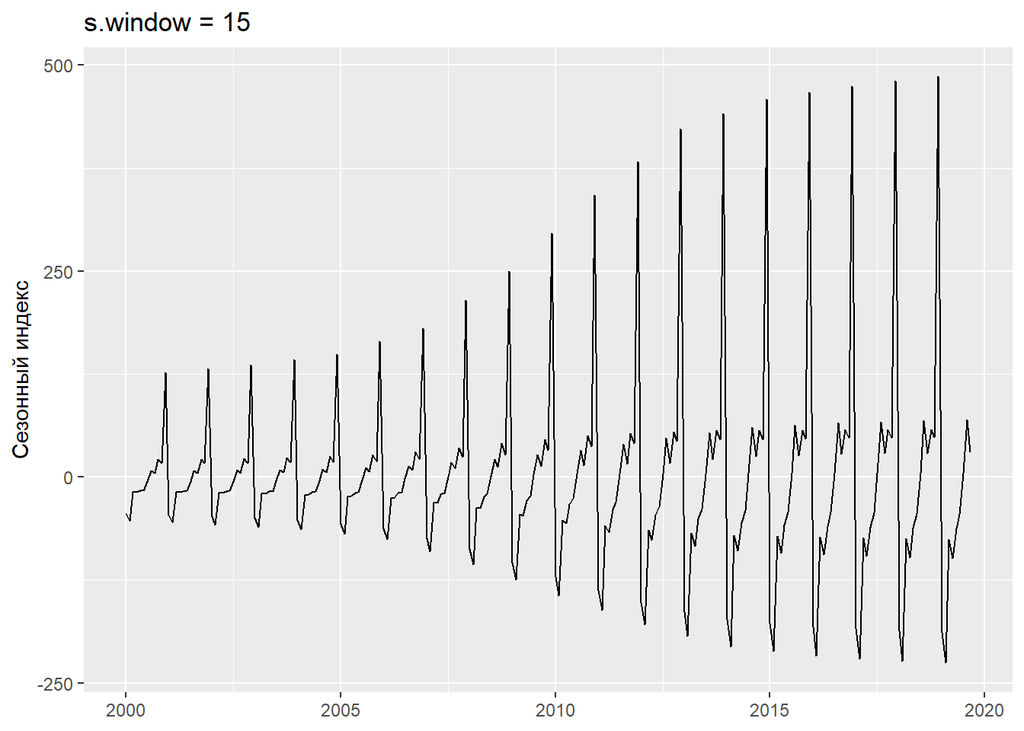

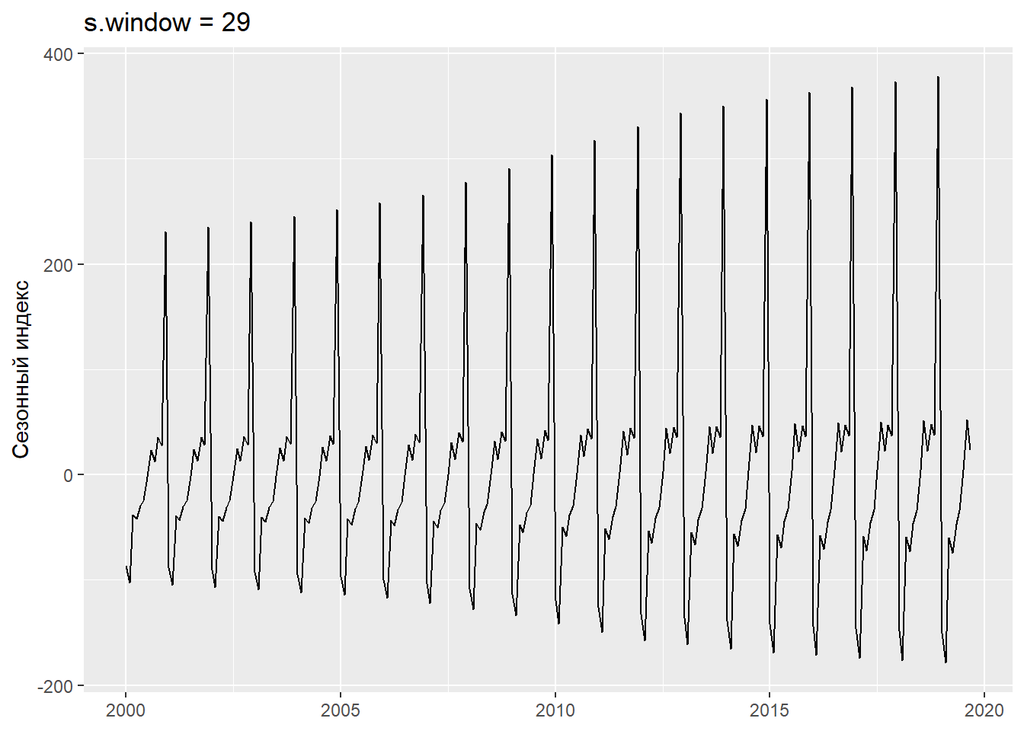

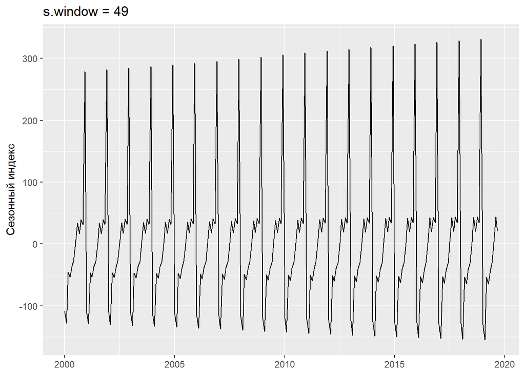

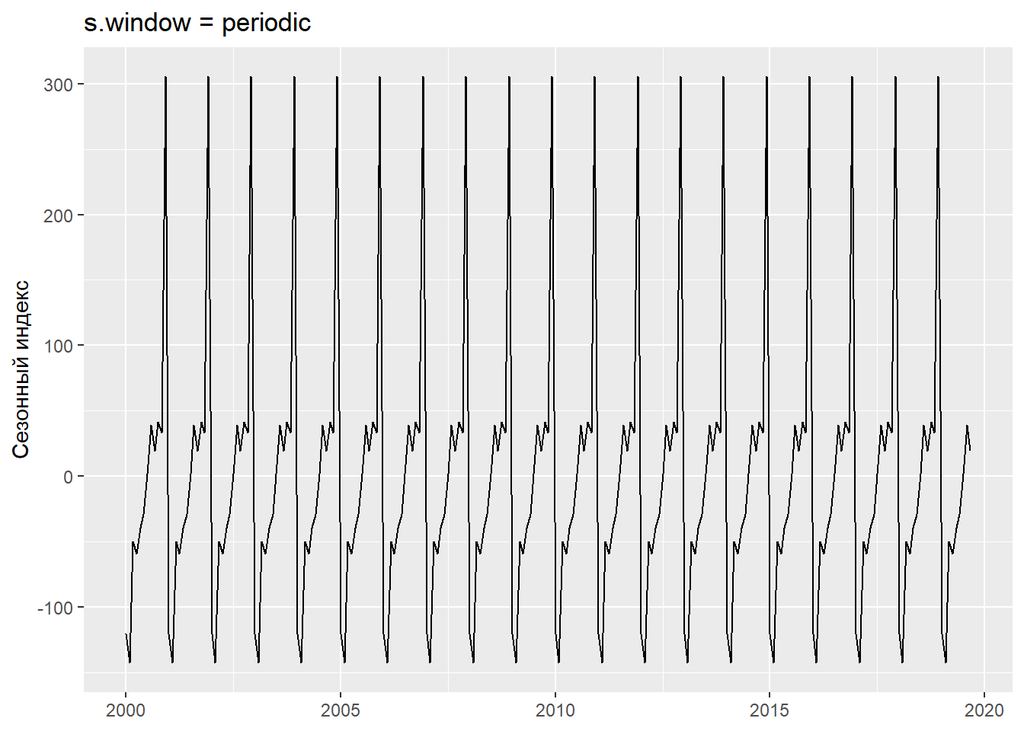

```r
# Ширина окна сглаживания w задается в цикле
for (w in list(7, 15, 29, 49, 'periodic')) {
  p <- autoplot(seasonal(stl(retail_ts, s.window = w))) +
    labs(title = str_c('s.window = ', w),
         x = NULL, y = 'Сезонный индекс')
  print(p)
}
```

Увеличение ширины окна сглаживания снижает скорость изменения сезонного компонента, однако это приводит к появлению сезонных колебаний в остатках модели.

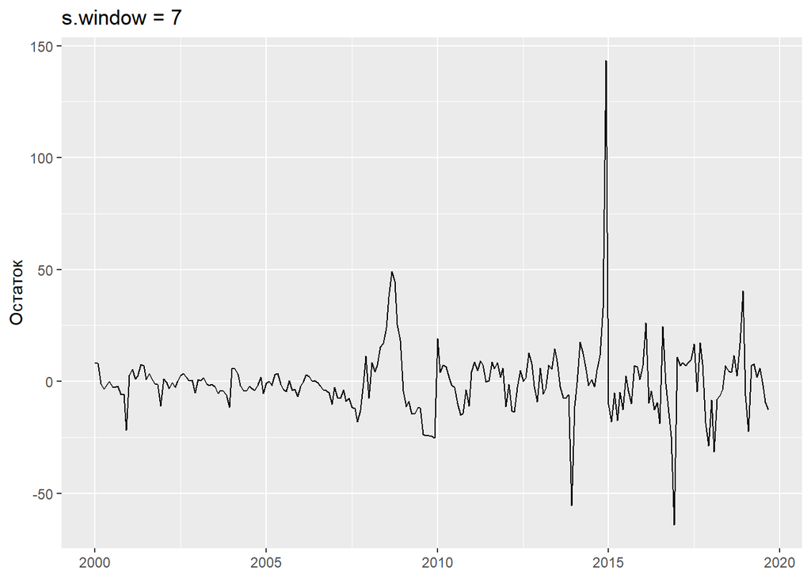

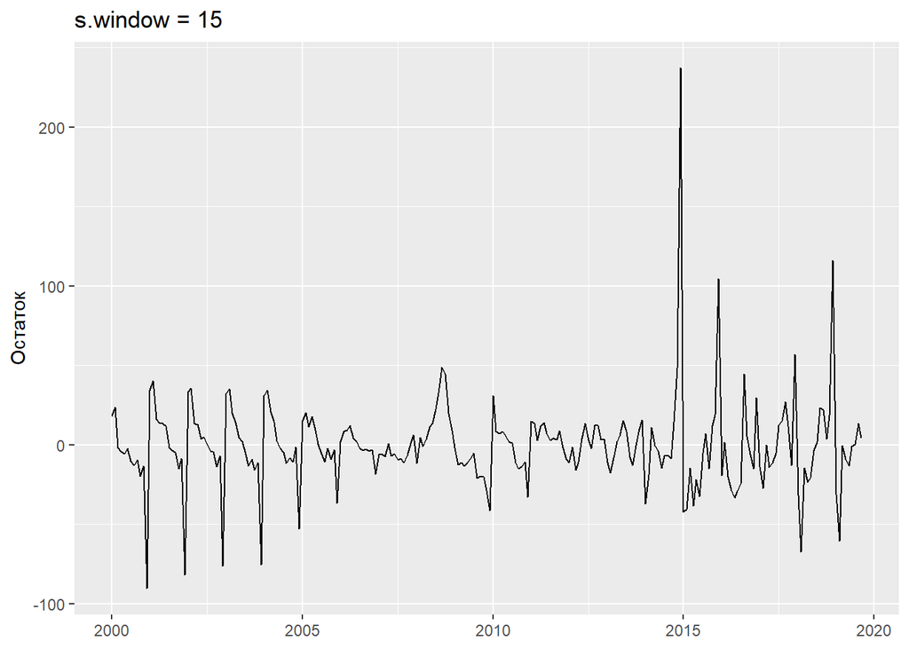

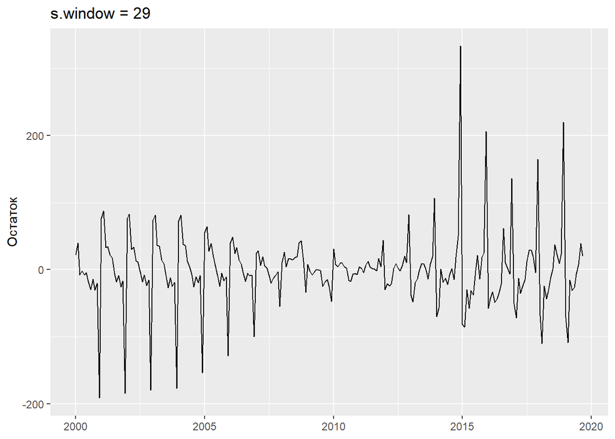

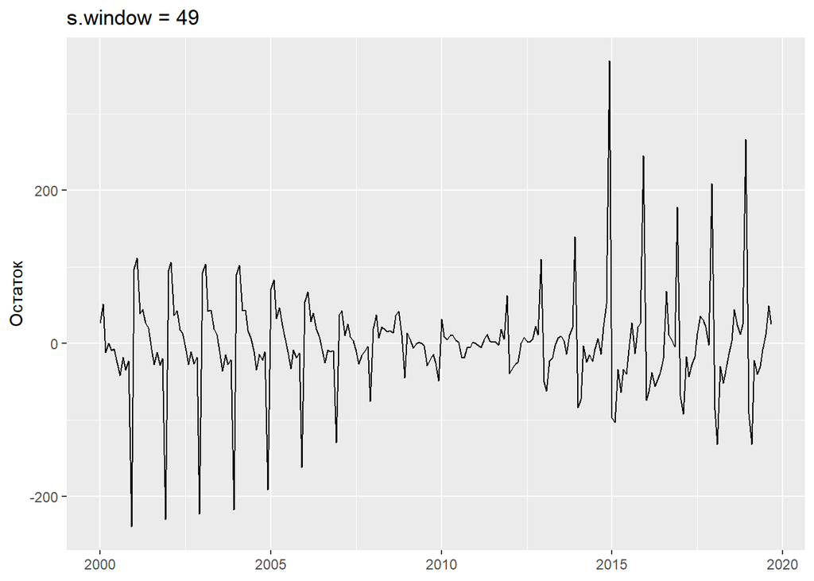

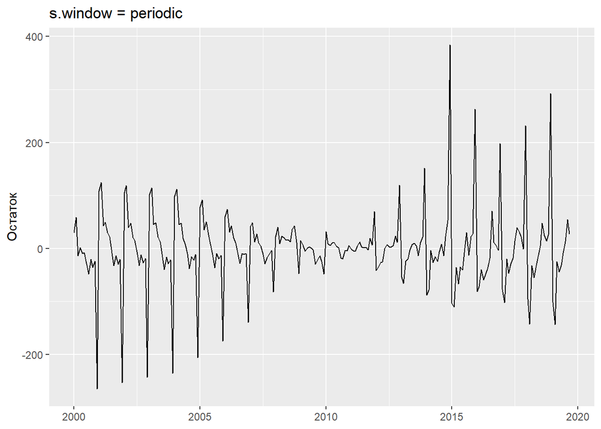

```r
# Ширина окна сглаживания w задается в цикле
for (w in list(7, 15, 29, 49, 'periodic')) {
  p <- autoplot(remainder(stl(retail_ts, s.window = w))) +
    labs(title = str_c('s.window = ', w),
         x = NULL, y = 'Остаток')
  print(p)
}
```

В данном случае ряд изменяется очень быстро, поэтому выберем минимальную ширину окна для сглаживания сезонных индексов - 7.

```r
retail_stl <- stl(retail_ts, s.window = 7)
```

Как и в случае с классической декомпозицией, отдельные компоненты ряда можно извлечь при помощи функций `seasonal()`, `trendcycle()` и `remainder()`.

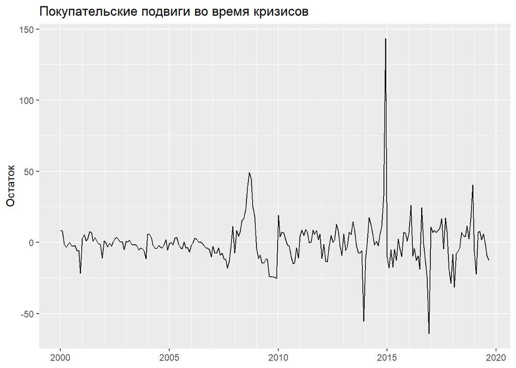

```r
retail_stl %>%
  remainder() %>%
  autoplot() +
    labs(title = 'Покупательские подвиги во время кризисов',
         x = NULL, y = 'Остаток') +
    scale_x_continuous(minor_breaks = start(retail_ts):end(retail_ts))
```

Сезонная корректировка ряда позволяет увидеть эти пики в масштабе исходных данных.

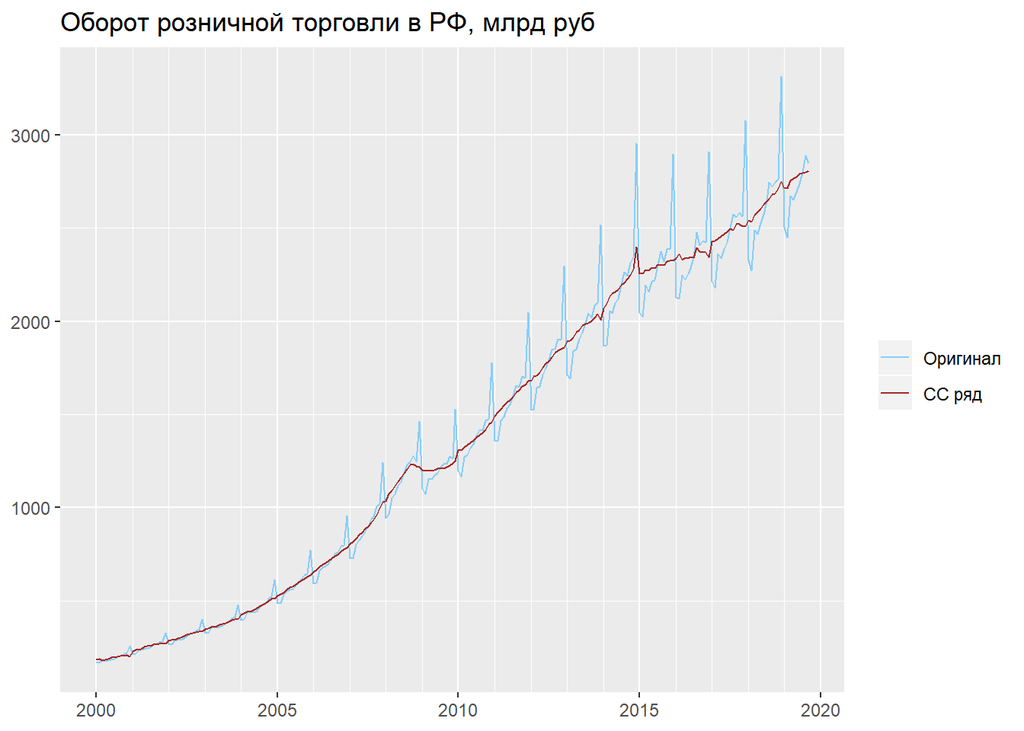

```r
autoplot(retail_ts, series = 'Оригинал') +
  autolayer(seasadj(retail_stl), series = 'СС ряд') +
  scale_colour_manual(values = c('lightskyblue', 'brown')) +
  labs(x = NULL, y = NULL, title = retail_title, color = NULL) +
  scale_x_continuous(minor_breaks = start(retail_ts):end(retail_ts))
```

### Логарифмирование

Другой способ обойти проблему мультипликативной сезонности - преобразование данных. При логарифмировании произведение компонент ряда заменяется на сумму логарифмов:

$$y = T \cdot S \cdot E \Rightarrow \log y = \log T + \log S + \log E$$

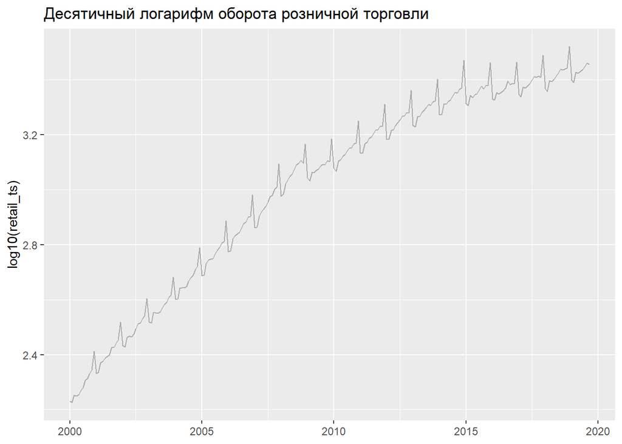

```r
autoplot(log10(retail_ts)) +
  labs(title = 'Десятичный логарифм оборота розничной торговли',
       x = NULL) +
  geom_line(color = 'darkgray')
```

Аддитивная модель лучше подходит к преобразованным с помощью логарифмирования данным.

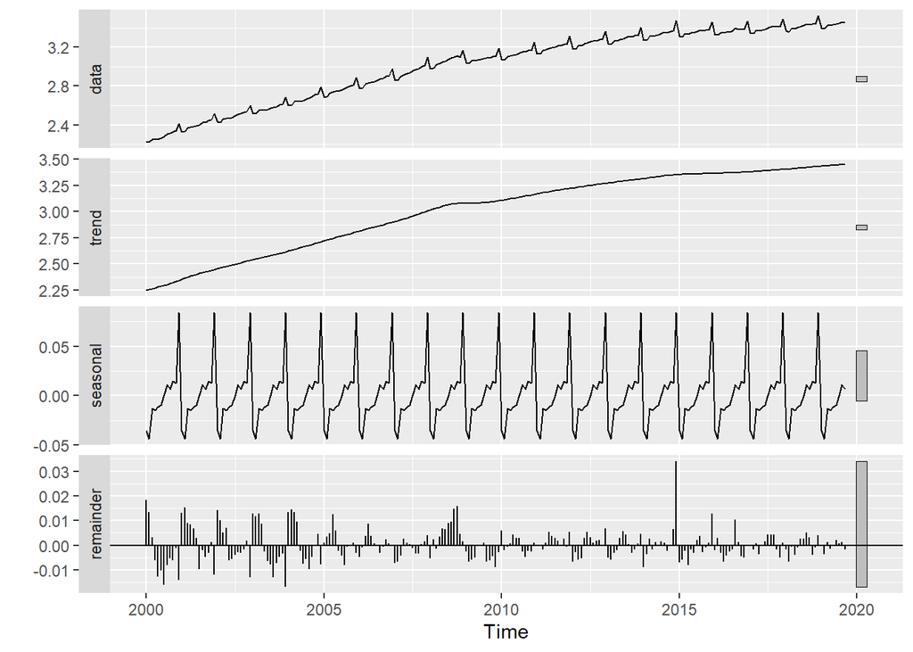

```r
retail_stl_log <-
  retail_ts %>%
  log10() %>%
  stl(s.window = 'periodic')

autoplot(retail_stl_log)
```

Данный подход неудобен тем, что для визуализации компонентов в исходном масштабе необходимо обратное преобразование - вычисление показательной функции. Также этот метод не применим, когда в исходных данных содержатся нули.

Чтобы сравнить модель ряда с исходными данными, необходимо выполнить обратное преобразование компонентов ряда - $10^x$.

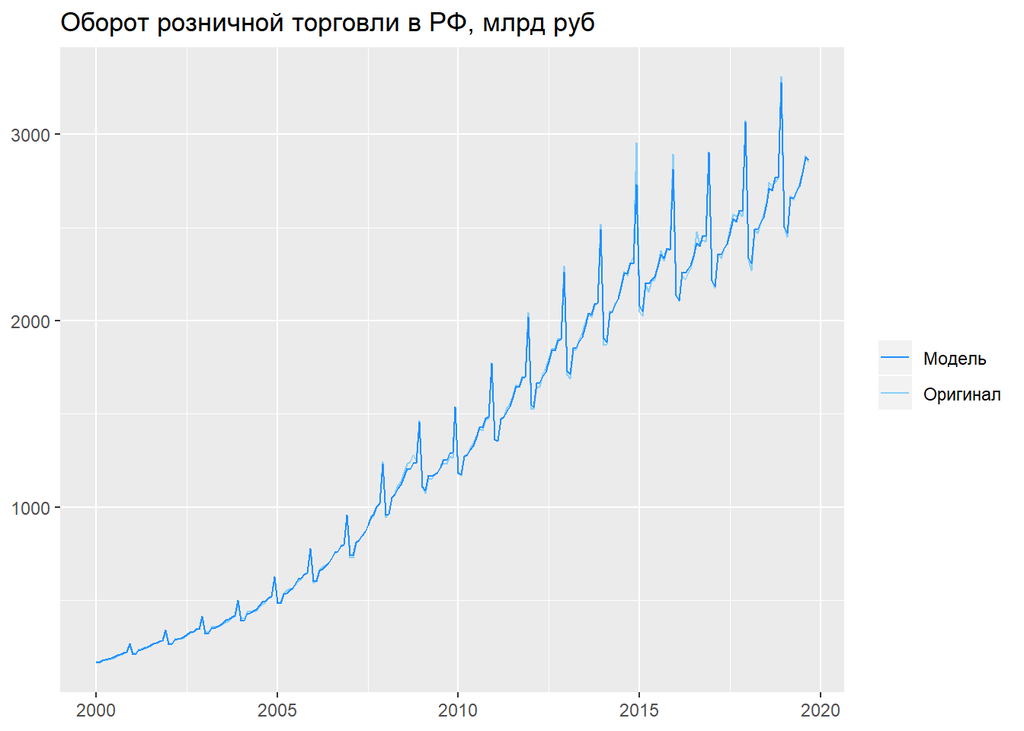

```r
retail_stl_fit <- 10^(trendcycle(retail_stl_log) +
                    seasonal(retail_stl_log))

autoplot(retail_ts, series = 'Оригинал') +
  autolayer(retail_stl_fit, series = 'Модель') +
  scale_colour_manual(values = c('dodgerblue', 'lightskyblue')) +
  labs(y = NULL, color = NULL, x = NULL,
       title = retail_title)
```